# Yukon River Fall Chum Salmon Inseason Mixed Stock Analysis

Project Leads: Bonnie Borba (bonnie.borba@alaska.gov)

17 September, 2024

# Pilot Station Passage

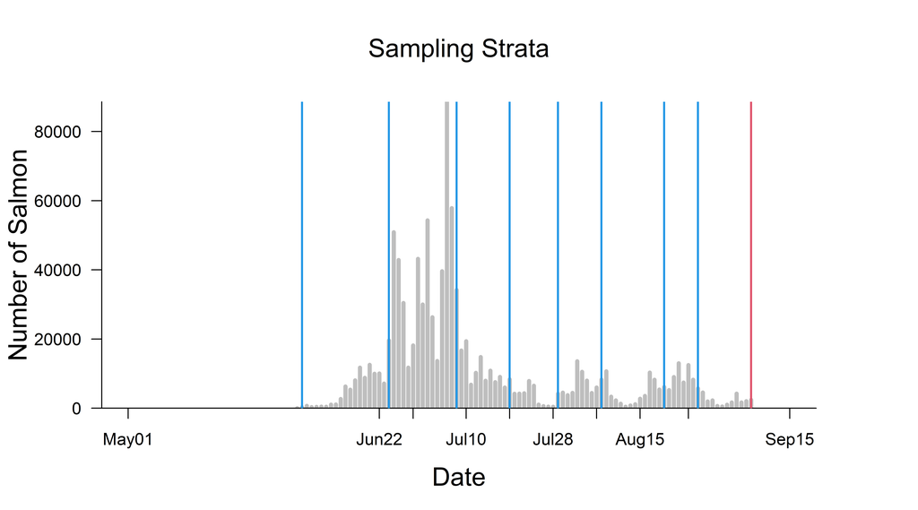

**Figure 1. Daily sonar counts attributed to chum salmon (bars) showing genetic sampling time frames (droplines), project operated near Pilot Station, Yukon Area, 2024.**

# Stock proportion by sampling strata

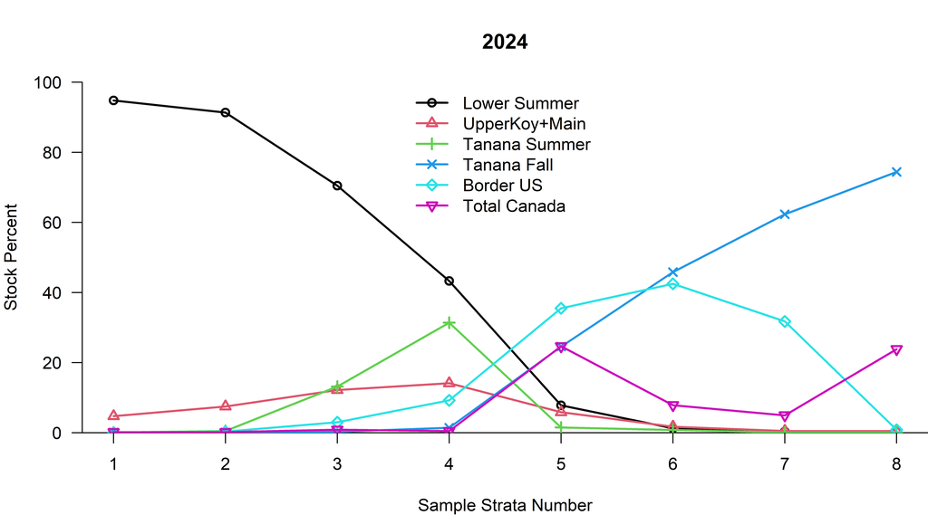

**Figure 2. Mean proportion of chum salmon stock groups by sampling strata, Yukon Area, 2024.**

## Stock proportion by strata (bar graph)

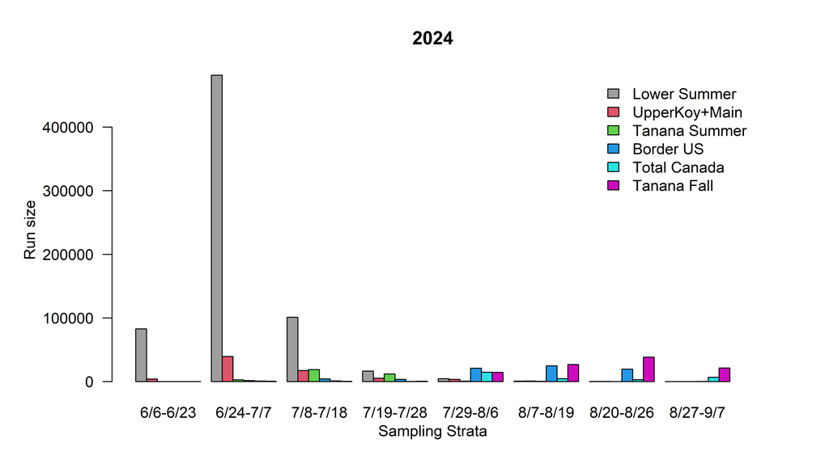

# Historical mean stock proportion

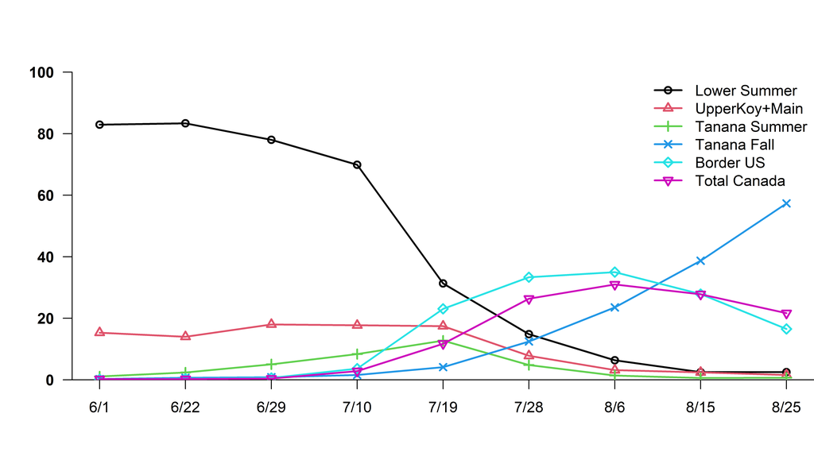

**Figure 3. Mean proportion of chum salmon stock groups by standard sampling strata, Yukon Area, 2004-2023.**

# Standard Stock Proportion

[figure not shown]

**Figure 4. Minimum and maximum (2004-2023) and 2024 mean stock proportion by standard sampling strata, comparing the major chum salmon components, Yukon Area.**

# Summer vs. Fall: All seasons

[figure not shown]

**Figure 5. Crossover of summer and fall chum salmon based on genetic stock analysis (standard sampling strata), Yukon Area, 1999-2002 using allozymes and 2004-2024 using microsatellites.**

## Summer vs. Fall: During the transition periods

[figure not shown]

**Figure 6. Crossover of summer and fall chum salmon (3 periods) based on genetic stock analysis (standard sampling strata), Yukon Area, 1999-2002 using allozymes and 2004-2024 using microsatellites.**

[figure not shown]

**Figure 7. Contributions of chum salmon based on genetic analysis during the fall season (July 19 to end of season), sampled at the mainstem sonar operated near Pilot Station, Yukon Area, 2024.**

# Tables

**Table 1. Genetic proportions of chum salmon stock groupings from samples collected from mainstem Yukon River (Pilot Station) sonar test fishery 2024.**

| Stock | Strata 1 6/6-6/23 n= 169 | Strata 2 6/24-7/7 n= 288 | Strata 3 7/8-7/18 n= 243 | Strata 4 7/19-7/28 n= 112 | Strata 5 7/29-8/6 n= 172 | Strata 6 8/7-8/19 n= 258 | Strata 7 8/20-8/26 n= 288 | Strata 8 8/27-9/7 n= 178 |
| --- | --- | --- | --- | --- | --- | --- | --- | --- |
| Lower Summer | 94.8 | 91.3 | 70.5 | 43.3 | 7.8 | 1.3 | 0.4 | 0.4 |
| UpperKoy+Main | 4.7 | 7.5 | 12.2 | 14.1 | 5.9 | 1.7 | 0.5 | 0.5 |
| Tanana Summer | 0.1 | 0.5 | 13.2 | 31.4 | 1.5 | 0.8 | 0.1 | 0.1 |
| Tanana Fall | 0.1 | 0.1 | 0.3 | 1.4 | 24.6 | 45.8 | 62.3 | 74.4 |
| Border US | 0.1 | 0.3 | 3.0 | 9.2 | 35.5 | 42.5 | 31.8 | 0.8 |
| Border CA | 0.1 | 0.1 | 0.8 | 0.3 | 23.0 | 4.2 | 2.4 | 23.5 |
| Porcupine CA | 0.0 | 0.0 | 0.2 | 0.0 | 19.4 | 1.8 | 1.2 | 8.3 |
| Mainstem CA | 0.1 | 0.1 | 0.6 | 0.2 | 3.6 | 2.4 | 1.2 | 15.1 |
| Upper Canada | 0.1 | 0.1 | 0.1 | 0.2 | 1.7 | 3.7 | 2.6 | 0.4 |
| White | 0.0 | 0.0 | 0.0 | 0.1 | 1.6 | 3.1 | 2.6 | 0.3 |
| Teslin | 0.0 | 0.0 | 0.0 | 0.1 | 0.1 | 0.6 | 0.0 | 0.1 |
| Total Summer | 99.6 | 99.4 | 95.8 | 88.8 | 15.2 | 3.8 | 0.9 | 0.9 |
| Total Middle | 4.8 | 8.0 | 25.4 | 45.5 | 7.4 | 2.5 | 0.6 | 0.6 |
| Total Fall | 0.4 | 0.6 | 4.2 | 11.2 | 84.8 | 96.2 | 99.1 | 99.1 |
| Fall US | 0.2 | 0.4 | 3.3 | 10.7 | 60.1 | 88.3 | 94.1 | 75.2 |
| Mainstem + Upper CA | 0.1 | 0.2 | 0.7 | 0.4 | 5.3 | 6.1 | 3.8 | 15.5 |
| Border US + Canada | 0.3 | 0.5 | 3.9 | 9.7 | 60.2 | 50.4 | 36.7 | 24.7 |
| Total USA | 99.8 | 99.8 | 99.1 | 99.5 | 75.3 | 92.1 | 95.0 | 76.2 |
| Total Canada | 0.2 | 0.2 | 0.9 | 0.5 | 24.7 | 7.9 | 5.0 | 23.8 |

**Table 2. Genetic estimates of chum salmon passage by stock groups applied to mainstem Yukon River (Pilot Station) sonar counts 2024.**

| Stock | Strata 1 6/6-6/23 n= 169 | Strata 2 6/24-7/7 n= 288 | Strata 3 7/8-7/18 n= 243 | Strata 4 7/19-7/28 n= 112 | Strata 5 7/29-8/6 n= 172 | Strata 6 8/7-8/19 n= 258 | Strata 7 8/20-8/26 n= 288 | Strata 8 8/27-9/7 n= 178 | Total |
| --- | --- | --- | --- | --- | --- | --- | --- | --- | --- |
| Lower Summer | 82,764 | 481,479 | 101,083 | 16,467 | 4,660 | 746 | 219 | 104 | 687,521 |
| UpperKoy+Main | 4,135 | 39,505 | 17,482 | 5,373 | 3,483 | 1,013 | 326 | 133 | 71,450 |
| Tanana Summer | 72 | 2,809 | 18,888 | 11,939 | 900 | 466 | 37 | 28 | 35,140 |
| Tanana Fall | 110 | 627 | 420 | 551 | 14,608 | 26,798 | 38,367 | 21,340 | 102,821 |
| Border US | 79 | 1,713 | 4,300 | 3,513 | 21,098 | 24,850 | 19,548 | 239 | 75,339 |
| Border CA | 86 | 569 | 1,139 | 109 | 13,658 | 2,434 | 1,469 | 6,729 | 26,195 |
| Porcupine CA | 18 | 84 | 237 | 16 | 11,541 | 1,056 | 725 | 2,393 | 16,070 |
| Mainstem CA | 68 | 485 | 902 | 93 | 2,118 | 1,379 | 744 | 4,336 | 10,125 |
| Upper Canada | 58 | 385 | 113 | 71 | 1,003 | 2,171 | 1,591 | 110 | 5,503 |
| White | 38 | 158 | 49 | 25 | 971 | 1,810 | 1,572 | 89 | 4,712 |
| Teslin | 20 | 227 | 65 | 47 | 32 | 361 | 19 | 21 | 791 |
| Total Summer | 86,971 | 523,793 | 137,453 | 33,778 | 9,043 | 2,225 | 581 | 266 | 794,110 |
| Total Middle | 4,207 | 42,314 | 36,370 | 17,311 | 4,383 | 1,479 | 363 | 161 | 106,589 |
| Total Fall | 334 | 3,294 | 5,972 | 4,245 | 50,367 | 56,253 | 60,975 | 28,419 | 209,859 |
| Fall US | 189 | 2,340 | 4,720 | 4,064 | 35,706 | 51,648 | 57,914 | 21,579 | 178,160 |
| Mainstem + Upper CA | 127 | 870 | 1,015 | 164 | 3,121 | 3,550 | 2,335 | 4,447 | 15,628 |
| Border US + Canada | 224 | 2,667 | 5,552 | 3,694 | 35,759 | 29,455 | 22,608 | 7,079 | 107,038 |
| Total USA | 87,160 | 526,133 | 142,173 | 37,842 | 44,749 | 53,873 | 58,495 | 21,845 | 972,270 |
| Total Canada | 145 | 954 | 1,252 | 181 | 14,661 | 4,605 | 3,061 | 6,840 | 31,699 |